# 出エジプト記

19/07/13

## プロローグ

## はじめに

- このスライドが映される頃には、私はきっとその場にはいないでしょう……
  - すべてのkagglerに栄光あれ――
- 作成者: きぬいと
  - RコンペとELOコンペでexpertになるような人間
    - スケジュール管理ができない

## 遺言の内容

- KKKPにかんする感動の物語
  - チームを組む(第1章)
  - エジプト入り(第2章)
  - エジプトでの迫害(第3章)
  - 出エジプト(第4章)
  - エピローグ

  をお話します

## LANL Earthquake Prediction

- 通称地震コンペ
  - rawdataが6億行とかいうのがたのしい
- 予測するのは「地震が起きるまでの時間(Time To Failure; TTF)」
- 予測のために利用するのは「圧力がかかっている機械の音(acoustic emission)」
- 指標はMAE
  - all-zero submissionでpublicの平均が割れるなどの楽しい出来事があった(公開論文)

## LANL Earthquake Prediction

- 公開論文があった
  - きぬいと的には初めての経験
- 結構なヒントがあったらしい
  - Time Since Failure(TTFの反転)を予測するのはうまくいく
  - MAE Hack(Public LBの正解データの平均がわかる)
- きぬいとがこれに気づくのはだいぶあとだった

## KKKPとは

- 地震コンペが本格的な初チームマージな集団
  - TokyoR(Rユーザコミュニティ)で知り合った人たち
  - 通称「TokyoRチーム」(by 某++)
- チームメンバーのうち2人はほぼ初コンペ
- チームメンバーのうち3人は資本が同じ社会人

## 登場人物

- Kumakichi(くまきち)
  - EDAを通したアイデアでエジプト入りを成し遂げた英雄
- Kur0cky(くろっきー)
  - Kumakichiのアイデアを具現化するエース
- tsuyuPon(つゆぽん)
  - AWSでrawdataをそのまま強引にEDAする豪腕
- Kien Knot(きぬいと)
  - JTMRCで愚痴ってるモブ
  - みんなR使ってる中イキってpython使うモブ

## 第1章 チームマージ

## チームマージのきっかけ

- きぬいと「地震コンペしません？」
  - くまきち「いまやってたわ」
  - つゆぽん「もう少ししたら手を出そうって思ってる」
  - 「「「チームとか組みたいね」」」
- とはいえ多少は個々で戦ってみたい
  - ブレンディングハイスコアkernel(1.448)を破る目標
  - モデルやアイデアを練りつつそこで落ち合おう的約束をした

## チームマージのきっかけ

- TokyoRにて
  - kur0cky「kaggleでチームとか組んでみたいです！」
  - きぬいと「なんかコンペあったら組みませう！」
- 地震コンペ
  - きぬいとの内心「もっと強い人に誘われてそうだなあ」
  - きぬいと「地震コンペ、ともにゆこうではないか」
  - kur0cky「うむ、ゆこう」
  - そういうことになった

## 第2章 初エジプト入り

## チームマージ後、アイデアを持ち寄る勢

- 公開Blending kernelを越えたきぬいとのkernelをベースに**kaggler**坂(神楽坂)に集結する
  - kaggler坂をkaggler坂っていうやつはみんなも使っていいですよ
  - 極端な上下が当たらないな
    - 極端な「下」を当てに行こう
  - 「地震」と定義されている時点の直前に起きている「何か」を予測できないか
    - 「子持ち昆布から卵がはがれる」やつを回避したいよね

## 参考: 子持ち昆布プロット

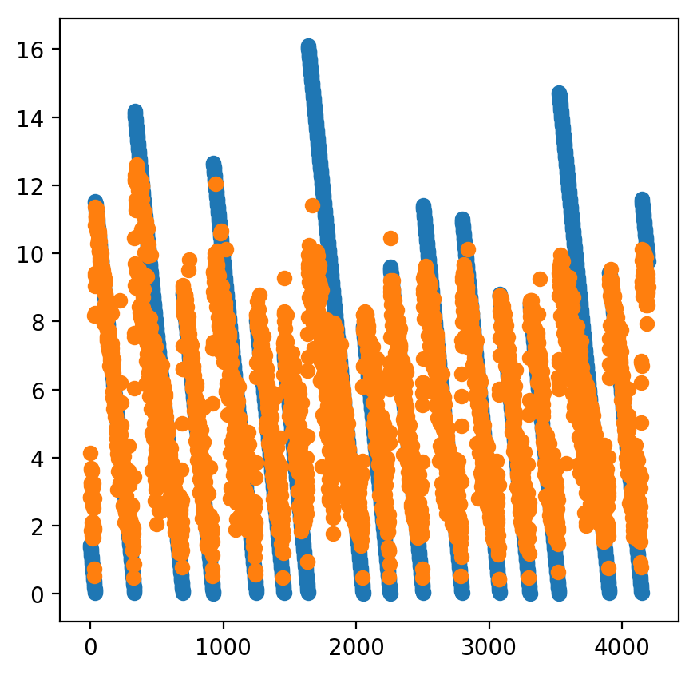

- これ(index横軸にした予実のプロット)
- 単純な予実縦横プロットよりも多用した

## とった戦略

- ベンチマーク(後述)の予測値で外しがちな極端な「下」を強引にそれっぽい値に置き換える

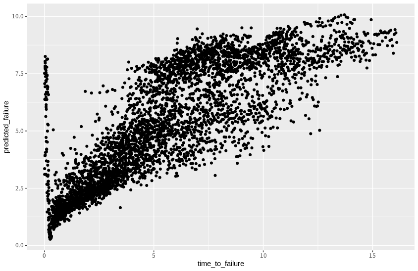

  こいつの0〜0.3付近を置き換えた

## ベンチマーク

- きぬいと担当
  - 多くのkernelをベースに作り上げたキメラ
    - ダメダメexpert特有のkernel錬金術
    - 特別な特徴量があるわけでもなく、単純に安定感のあるモデルだった(はず)
  - LightGBMでgammaタスクを解かせていた
    - 精度も高く上位圏のSolutionでもgammaタスクだった
    - が多数派に呑まれてfairとかhuberとかに流れてしまい伸びず(そこはあまり関係ない)

## 結果

- public1.337

[figure not shown]

## 第3章 エジプトでの迫害

## ここから伸びない(あたりまえ)

- アイデアは出るがうまく形にならない
- どんどん後続に抜かれる
  - 最終的に銀圏までジリジリと落とされる
- CPMP「特徴量7つとかでいけるんだが？？？？」
  - 実験データだしそこまでひねりのある特徴量や複雑なStackingとかいらない
  - きぬいと、変にこだわりだす

## kumakichiの才覚

- 「Time to FailureよりTime since Failureのほうが予測しやすいんじゃないか」
  - 公開論文にも指摘があった目的変数の変換
  - [カレーさんSolution](https://twitter.com/currypurin/status/1135707415641374720)の一部

  (もうちょい深堀れればUAEあたりで済んだかもしれない)
- 一方きぬいとはアイデア力も技術力も追いつかなくなる
  - 苦し紛れのKNRegを2時間で実装するなど(モデル的に活かせなかった)

## 最終日夜

- きぬいと「力尽きました」
  - みんな「は？」
- Kumakichi & Kur0cky、世を徹して最後のsubmitに挑む
- 最終的にきぬいとのFinal Submissionに委ねられる
  - リアルガチで3時間悩むやつをした
- Trust CVか、Trust PBか……
  - 今思えばDiscussionで散々「PBは信用できん」って言われてたんだよね

## 第4章 出エジプト

## 最終的なSubmission

- エジプトの思い出(Public 1.337)
- 最終日の追い込み(Public 1.492)

## AM 9:00

- Before(Public 70th)

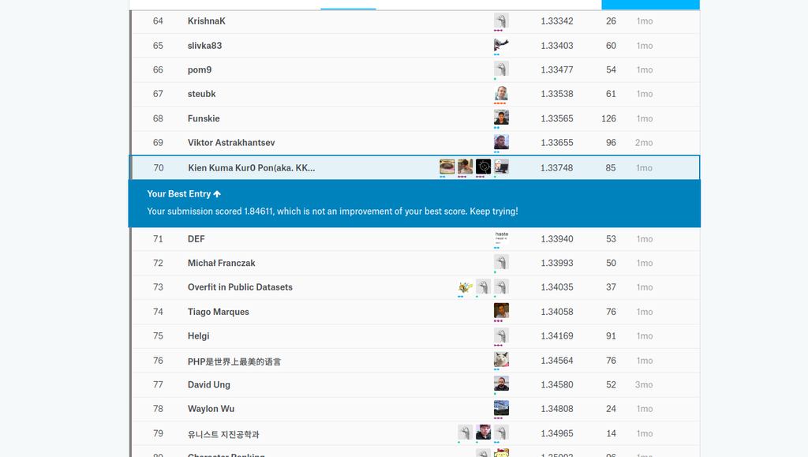

## AM 9:00

- After(Private 831st)

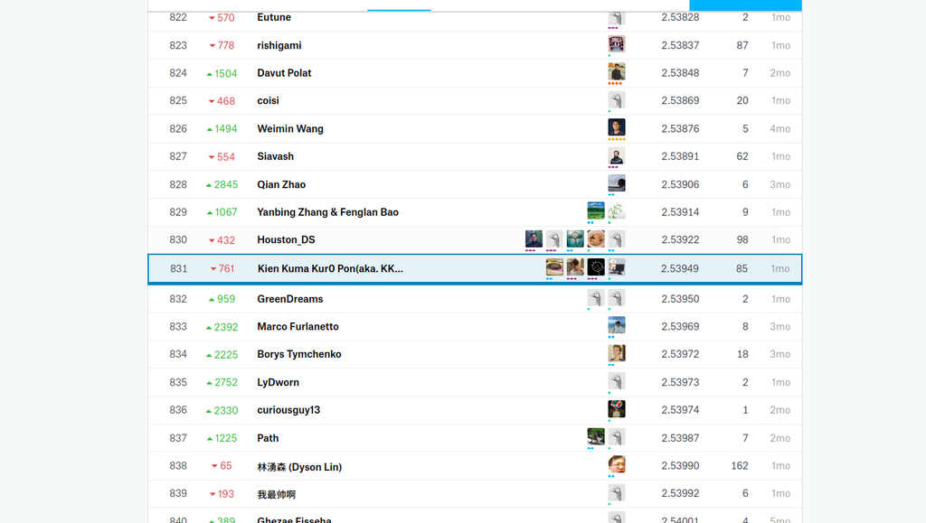

## AM 9:00

- や さ い
  - なお最終日追い込みのほうが採択されていた
  - エジプト入りは2.676
- Local CVを信じていなければもっと落ちていた

## エピローグ

## 全体的に

- 地震コンペだけにものすごく揺れた
  - 上位勢が片っ端から吹っ飛ぶ
  - なぜかCPMPとGibaが残る
    - Gibaに至ってはShake upしている
  - kaggle GMこわいこわいだね
- 上位勢のSolutionも「なんだそれいみわからん」って感じの内容はそんなない
  - Trust our CVを信じつつ、やるべきことをやるとエジプト入りする

## 私達は

- 70th → 831st
  - 強引なPostprocessingは良くない感じであった
  - むしろ予測値全体に重みづけたりなんなりするほうが良かった
  - Trust your CVが座右の銘になった
- Late subベンチマークに[Giba式Postprocessing](https://www.kaggle.com/c/LANL-Earthquake-Prediction/discussion/94466#latest-552715)
  - 銀圏スコアが出たりした
  - 予測してから先の戦略も学んだ
- 全員初チームマージ←これ
  - ワイワイできたし確かに集合知はあった。
    - けどうまい連携はとれなかった……
  - @チーム慣れしてる各位 どう連携してるか教えてほしい

## 感想

- きぬいと「いいけいけんだった。つぎはもっとうまくやるさ」
- くまきち「高揚感に呑まれて情報収集をサボると**自尊心全損**オチが待ってることが分かりました！つらいです！」
- くろっき「チーム戦楽しくて学会の準備していない……」
- つゆぽん「Weight0, but cost 10k(JPY)」